# Assignment3

Ville Lehtonen

May 28, 2020

# Assignment 3: Predicting protein location

### Question 1

```r
# Read data into a dataframe
f <- file.path('data', 'ecoli.data')
ecoli_data <- read.delim(file = f,
                         comment.char = "#",
                         header = TRUE,
                         sep = "\t")

# Inspect if any duplicates are found in the data
any(duplicated(ecoli_data))
```

```
## [1] FALSE
```

```r
# Create the table of frequencies of different locations
location_tbl <- as.data.frame(table(ecoli_data$location))
colnames(location_tbl) <- c("Abbr", "Number")
location_tbl <- location_tbl[order(-location_tbl$Number), ]

# Inspect data and print a summary of the table
skimr::skim(ecoli_data)
```

Data summary

| Name | ecoli_data |
| --- | --- |
| Number of rows | 336 |
| Number of columns | 9 |
| _______________________ |  |
| Column type frequency: |  |
| factor | 2 |
| numeric | 7 |
| ________________________ |  |
| Group variables | None |

**Variable type: factor**

| skim_variable | n_missing | complete_rate | ordered | n_unique | top_counts |
| --- | --- | --- | --- | --- | --- |
| SpAccNr | 0 | 1 | FALSE | 336 | AAS: 1, AAT: 1, ACE: 1, ACE: 1 |
| location | 0 | 1 | FALSE | 8 | cp: 143, im: 77, pp: 52, imU: 35 |

**Variable type: numeric**

| skim_variable | n_missing | complete_rate | mean | sd | p0 | p25 | p50 | p75 | p100 | hist |
| --- | --- | --- | --- | --- | --- | --- | --- | --- | --- | --- |
| mcg | 0 | 1 | 0.5 | 0.19 | 0.00 | 0.34 | 0.50 | 0.66 | 0.89 | ▁▆▇▇▃ |
| gvh | 0 | 1 | 0.5 | 0.15 | 0.16 | 0.40 | 0.47 | 0.57 | 1.00 | ▁▇▅▂▁ |
| lip | 0 | 1 | 0.5 | 0.09 | 0.48 | 0.48 | 0.48 | 0.48 | 1.00 | ▇▁▁▁▁ |
| chg | 0 | 1 | 0.5 | 0.03 | 0.50 | 0.50 | 0.50 | 0.50 | 1.00 | ▇▁▁▁▁ |
| aac | 0 | 1 | 0.5 | 0.12 | 0.00 | 0.42 | 0.50 | 0.57 | 0.88 | ▁▁▇▅▁ |
| alm1 | 0 | 1 | 0.5 | 0.22 | 0.03 | 0.33 | 0.46 | 0.71 | 1.00 | ▂▇▅▅▂ |
| alm2 | 0 | 1 | 0.5 | 0.21 | 0.00 | 0.35 | 0.43 | 0.71 | 0.99 | ▁▇▆▅▂ |

```r
# Print the location table
location_tbl %>%
  knitr::kable(format="html", caption="Table 1: Frequencies of locations for E.Coli") %>%
  kableExtra::kable_styling()
```

Table 1: Frequencies of locations for E.Coli

|  | Abbr | Number |
| --- | --- | --- |
| 1 | cp | 143 |
| 2 | im | 77 |
| 8 | pp | 52 |
| 5 | imU | 35 |
| 6 | om | 20 |
| 7 | omL | 5 |
| 3 | imL | 2 |
| 4 | imS | 2 |

**Answer to Q1**:

- It seems that no duplicates are found from the data set
- The frequencies of locations in the data are shown in Table 1

### Question 2

```r
# Remove locations with low observations (imL, imS)
library(dplyr)
ecoli_data_filtered <- ecoli_data %>%
  filter(location != "imL", location != "imS")

# Remove unused locations
ecoli_data_filtered$location <- factor(ecoli_data_filtered$location)
```

**Answer to Q2:** :

- In stratified sampling, we aim to ensure that each partition has approximately the same amount of samples of each target class (location)
- 4-fold CV was used for the E.Coli data set so the split between training and test data is 75% / 25%. This means that on average for a location to occur at least twice (>= 2) in the stratified training set, it needs to be present at least 3 times in the whole data.
- Based on this, we want to remove the locations ‘imL’ and ‘imS’, which both occur only two times in the data set. If we didn’t do this, some test sets might have zero observations from these locations

### Question 3

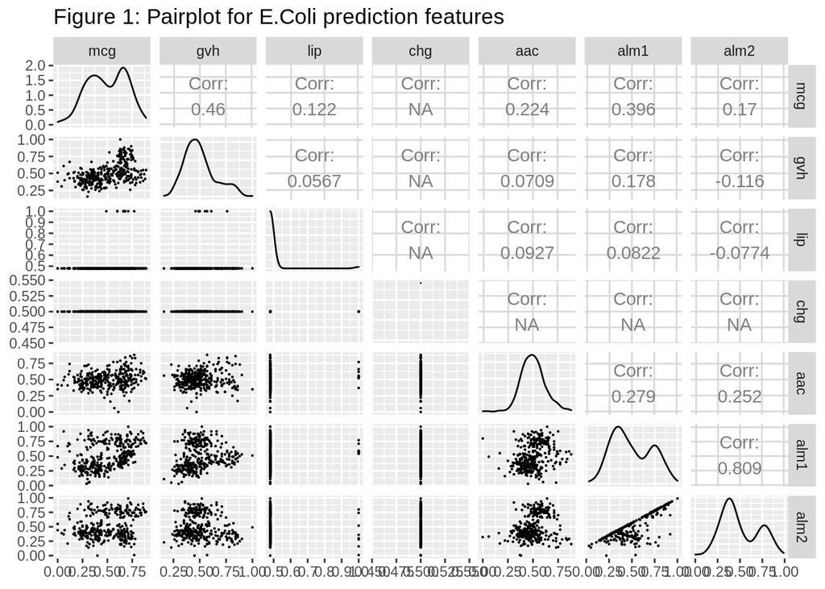

```r
# Make a pairplot of the filtered data
library(GGally)

ecoli_pairplot <- ggpairs(data = ecoli_data_filtered %>% select(-location, -SpAccNr),
                          title = "Figure 1: Pairplot for E.Coli prediction features",
                          lower = list(continuous = wrap("points", size = 0.1)))

print(ecoli_pairplot)
```

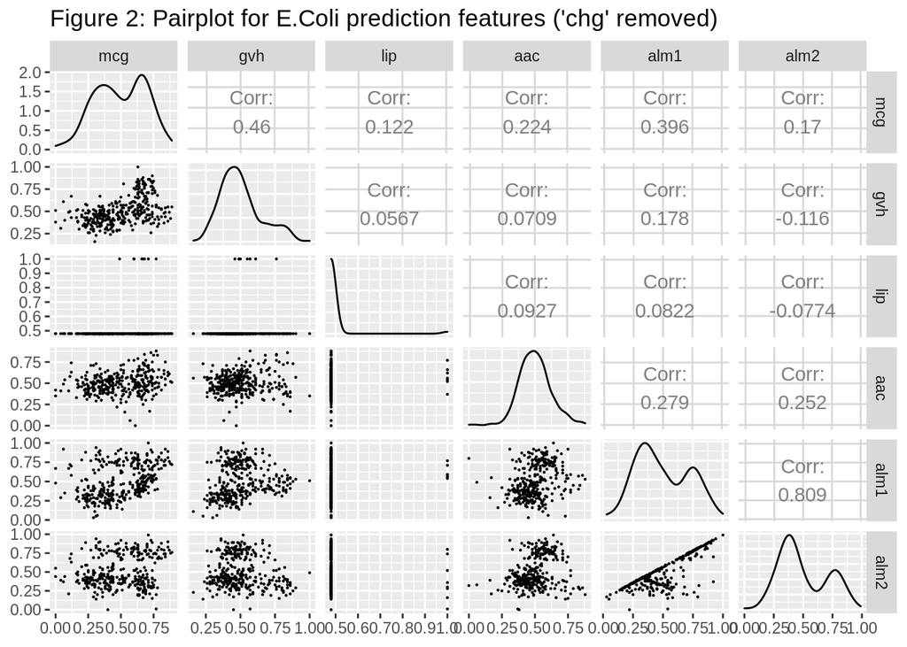

```r
# Remove chg as it has no predictive power
ecoli_data_filtered <- ecoli_data_filtered %>%
  select(-chg)

# Make a new pairplot
ecoli_pairplot2 <- ggpairs(data = ecoli_data_filtered %>% select(-location, -SpAccNr),
                          title = "Figure 2: Pairplot for E.Coli prediction features ('chg' removed)",
                          lower = list(continuous = wrap("points", size = 0.1)))

print(ecoli_pairplot2)
```

**Answer to Q3:**

- Above are shown 2 pairplots. The first one is one with all the predictor features included and the latter one is a one where ‘chg’ feature is left out as it doesn’t have any predictive power due to having a constant value in every sample.

Findings:

- Based on the results of the pairplot, it seems that some features are highly or somewhat correlated. For instance, alm1 and alm2 are highly positively correlated with each other (Corr: 0.809). Ncg and gvg also have somewhat high correlation (0.46) as well as alm1 and mcg (0.396). In addition, many features show slight correlations with each other.
- Multicollinearity of features will be a problem especially for KNN and Naive Bayes algorithms and this can lead to misleading results. Random forest, which builds an ensemble of decision trees, should be immune to this problem as in each split the decision are made so that only one of the correlated features is selected.
- chg produces only NAs in the original pairplot since it has a constant value and thus no predictive power.

Actions to be taken:

- To deal with the correlation of features, we would usually do either dimension reduction (PCA) or feature selection. In this case, as the number of features is already rather small, feature selection is a suitable approach.
- Next, we’ll calculate the VIF (variance inflation factor) for each feature to score the correlation between features and to determine which features could be removed from the set of predictor features.

**Feature selection:**

```r
library(car)
# Prepare data for feature selection
d <- ecoli_data_filtered %>% select(-SpAccNr)
d$location <- as.numeric(d$location)

# Fit a model and inspect aliases in the linear model
lm.fit <- lm(location ~ ., data = d)
vif_scores <- vif(lm.fit)
print(vif_scores)
```

```
##      mcg      gvh      lip      aac     alm1     alm2
## 1.505490 1.496277 1.089720 1.118782 4.233403 3.933248
```

```r
# As it seems that alm1 is highly correlated with alm2 and has highest VIF score, it can be filtered out from the predictor features
ecoli_data_filtered <- ecoli_data_filtered %>%
  select(-alm1)

# Fit a new model
d <- ecoli_data_filtered %>% select(-SpAccNr)
d$location <- as.numeric(d$location)
lm.fit <- lm(location ~ ., data = d)
vif_scores <- vif(lm.fit)
print(vif_scores)
```

```
##      mcg      gvh      lip      aac     alm2
## 1.409336 1.334719 1.034852 1.117506 1.154924
```

```r
#-> VIF scores seems to be fine

# print summary of the model to see p-values
print(summary(lm.fit))
```

```
##
## Call:
## lm(formula = location ~ ., data = d)
##
## Residuals:
##     Min      1Q  Median      3Q     Max
## -3.6640 -0.7655 -0.0533  0.6279  4.9520
##
## Coefficients:
##             Estimate Std. Error t value Pr(>|t|)
## (Intercept)  -2.5181     0.5035  -5.001 9.34e-07 ***
## mcg           3.5683     0.3807   9.373  < 2e-16 ***
## gvh           6.0737     0.4825  12.588  < 2e-16 ***
## lip           1.6766     0.7921   2.117  0.03505 *
## aac          -0.3639     0.5346  -0.681  0.49658
## alm2         -0.9436     0.3201  -2.948  0.00343 **
## ---
## Signif. codes:  0 '***' 0.001 '**' 0.01 '*' 0.05 '.' 0.1 ' ' 1
##
## Residual standard error: 1.131 on 326 degrees of freedom
## Multiple R-squared:  0.6074, Adjusted R-squared:  0.6013
## F-statistic: 100.9 on 5 and 326 DF,  p-value: < 2.2e-16
```

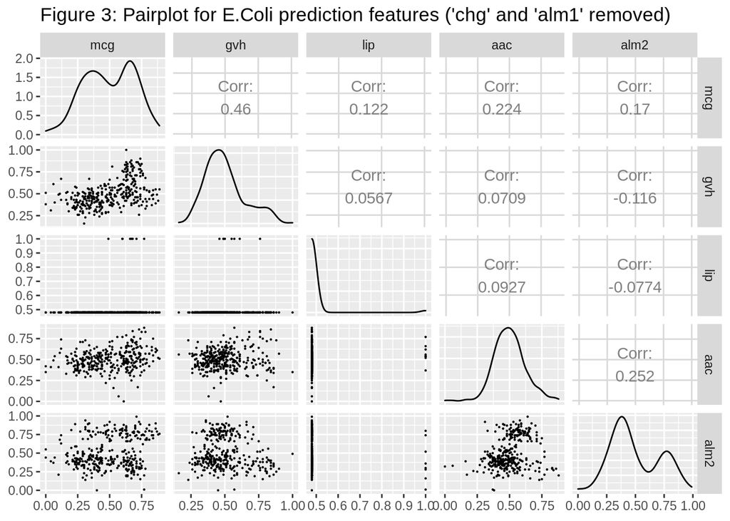

```r
# Make a new pairplot
ecoli_pairplot3 <- ggpairs(data = ecoli_data_filtered %>% select(-location, -SpAccNr),
                          title = "Figure 3: Pairplot for E.Coli prediction features ('chg' and 'alm1' removed)",
                          lower = list(continuous = wrap("points", size = 0.1)))

print(ecoli_pairplot3)
```

### Question 4

```r
# Get required libraries
library(class)
library("e1071")
library(randomForest)
library(tibble)

# source the partition function
fpart <- file.path("script", "partition_function.R")
source(fpart)

#################################################
#UTILITY FUNCTIONS USED IN THIS SCRIPT
#################################################

# Function to create a nested list
create_nested_list <- function(names, list_length){
  result <- lapply(names,
                   function(i){vector(mode = "list", length = list_length)})
  names(result) <- names
  return(result)
}
#################################################
# Set seed to produce constant results
set.seed(42)

# Perform stratified sampling
plabel <- partition(4, ecoli_data_filtered$location)

# Add the fold information to the filtered Ecoli data
ecoli_data_folds <- ecoli_data_filtered %>%
  mutate(fold = plabel)

# Create lists to store the results of the CV
names_of_models <- c("KNN",'NaiveBayes','RF') # Names of the models used
list_of_models <- create_nested_list(names_of_models, 4) # list to store models
list_of_pred <- create_nested_list(names_of_models, 4) # list to store predictions
list_of_prediction_scores <- create_nested_list(names_of_models, 4)  # list to store pred. scores

# 4-fold CV using stratified training and test sets
for(i in 1:4) {
  testset <- ecoli_data_folds %>% filter(fold == i) %>% select(-fold, -SpAccNr)
  trainset <- ecoli_data_folds %>% filter(fold != i) %>% select(-fold, -SpAccNr)

  #KNN
  knn_pred = knn(train = trainset[, -length(trainset)],
                  test = testset[, -length(trainset)],
                  cl = trainset[["location"]],
                  k = 7)
  correct_knn <- sum(knn_pred == as.character(testset[["location"]])) / dim(testset)[1]

  # Naive bayes
  nb <- naiveBayes(location ~ ., data = trainset)
  nb_pred <- predict(nb, testset)
  correct_nb <- sum(nb_pred == as.character(testset[["location"]])) / dim(testset)[1]

  # Random Forest
  rf <- randomForest(location ~ ., data = trainset)
  rf_pred <- as.factor(as.vector(predict(rf, testset)))
  correct_rf <- sum(rf_pred == as.character(testset[["location"]])) / dim(testset)[1]


  # Store the results
  list_of_pred[["KNN"]][[i]] <- knn_pred
  list_of_prediction_scores[["KNN"]][[i]] <- correct_knn

  list_of_models[["NaiveBayes"]][[i]] <- nb
  list_of_pred[["NaiveBayes"]][[i]] <- nb_pred
  list_of_prediction_scores[["NaiveBayes"]][[i]] <- correct_nb

  list_of_models[["RF"]][[i]] <- rf
  list_of_pred[["RF"]][[i]] <- rf_pred
  list_of_prediction_scores[["RF"]][[i]] <- correct_rf
}

# Create the table of accuracies
list_of_accuracy_tables = create_nested_list(names_of_models, 1) # list to store models

for (method in names(list_of_prediction_scores)) {
  accuracy_tbl <- list_of_prediction_scores[[method]] %>%
    as.data.frame() %>%
    t() %>%
    as_tibble() %>%
    rownames_to_column(var = "Partition") %>%
    rename("Accuracy" = "V1")

  list_of_accuracy_tables[[method]] <- accuracy_tbl
}

# Create a table of all the partition (1-4) results
result_tbl <- data.frame(
  Partition = c(1:4),
  KNN = list_of_accuracy_tables[["KNN"]]$Accuracy,
  NaiveBayes = list_of_accuracy_tables[["NaiveBayes"]]$Accuracy,
  RF = list_of_accuracy_tables[["RF"]]$Accuracy
)

# Create the table of means & std. devs for each method
means <- data.frame("mean", mean(result_tbl$KNN), mean(result_tbl$NaiveBayes), mean(result_tbl$RF))
names(means) <- c("Partition", "KNN", "NaiveBayes", "RF")

std.devs <- data.frame("std.dev.", sd(result_tbl$KNN), sd(result_tbl$NaiveBayes), sd(result_tbl$RF))
names(std.devs) <- c("Partition", "KNN", "NaiveBayes", "RF")

result_tbl.mean <- rbind(result_tbl, means)
result_tbl.mean.sd <- rbind(result_tbl.mean, std.devs)

# Print the final output table
result_tbl.mean.sd %>%
  knitr::kable(format="html", caption="Table 2: E.Coli data - Results of CV shown in accuracy, including the means and standard deviations") %>%
  kableExtra::kable_styling()
```

Table 2: E.Coli data - Results of CV shown in accuracy, including the means and standard deviations

| Partition | KNN | NaiveBayes | RF |
| --- | --- | --- | --- |
| 1 | 0.8674699 | 0.8554217 | 0.8554217 |
| 2 | 0.8674699 | 0.8313253 | 0.8795181 |
| 3 | 0.8072289 | 0.7951807 | 0.8554217 |
| 4 | 0.8795181 | 0.8433735 | 0.8674699 |
| mean | 0.8554217 | 0.8313253 | 0.8644578 |
| std.dev. | 0.0326267 | 0.0260271 | 0.0115353 |

**Answer to Q4**:

- According to the results shown in Table 2, RF seems to have the highest mean accuracy (~86%), KNN being a close second with ~85.5% and Naive Bayes has the lowest accuracy of ~83%
- KNN has the highest standard deviation (~0.03) and its worst accuracy score is ~80% as compared to the worst scores of Naive Bayes and RF, which were ~79% and ~85% respectively.

### Question 5

```r
set.seed(42)

t.knn.nb <- t.test(result_tbl$KNN, result_tbl$NaiveBayes, paired = TRUE)
t.knn.rf <- t.test(result_tbl$KNN, result_tbl$RF, paired = TRUE)
t.nb.rf <- t.test(result_tbl$NaiveBayes, result_tbl$RF, paired = TRUE)

t.test.table <- data.frame(
  KNN = c(NA, t.knn.nb$p.value, t.knn.rf$p.value),
  NaiveBayes = c(t.knn.nb$p.value, NA, t.nb.rf$p.value),
  RF = c(t.knn.rf$p.value, t.nb.rf$p.value, NA)
)

rownames(t.test.table) <- c("KNN", "NaiveBayes", "RF")

# Print the table of t-tests
t.test.table %>%
  knitr::kable(format="html", caption="Table 3: T-tests for each method (E.Coli)") %>%
  kableExtra::kable_styling()
```

Table 3: T-tests for each method (E.Coli)

|  | KNN | NaiveBayes | RF |
| --- | --- | --- | --- |
| KNN | NA | 0.0405193 | 0.5706565 |
| NaiveBayes | 0.0405193 | NA | 0.0892358 |
| RF | 0.5706565 | 0.0892358 | NA |

**Answer to Q5:**

- As can be seen from the Table 3, when using a p-value cutoff of 0.05, it seems that the difference between KNN and RF is not significant.
- However, the difference between KNN and Naive bayes (p = ~0.04) is considered to be significant. The difference between RF and Naive Bayes (0.08) would in this case be considered as non-signifcant.

### Question 6

```r
f2 <- file.path('data', 'yeast.data')
yeast_data <- read.delim(file = f2,
                         comment.char = "#",
                         header = TRUE,
                         sep = "\t")

# Inspect if any duplicates exist
any(duplicated(yeast_data))
```

```
## [1] TRUE
```

```r
rows <- dim(yeast_data)[1]

# Remove duplicates
yeast_data <- yeast_data[!duplicated(yeast_data), ]
duplicate_rows <- rows - dim(yeast_data)[1]
print(paste0("Amount of duplicates removed: ", duplicate_rows))
```

```
## [1] "Amount of duplicates removed: 22"
```

```r
# Create the table of frequencies of different locations
location_tbl2 <- as.data.frame(table(yeast_data$location))
colnames(location_tbl2) <- c("Abbr", "Number")
location_tbl2 <- location_tbl2[order(-location_tbl2$Number), ]

# Inspect data and print a summary of the table
skimr::skim(yeast_data)
```

Data summary

| Name | yeast_data |
| --- | --- |
| Number of rows | 1462 |
| Number of columns | 10 |
| _______________________ |  |
| Column type frequency: |  |
| factor | 2 |
| numeric | 8 |
| ________________________ |  |
| Group variables | None |

**Variable type: factor**

| skim_variable | n_missing | complete_rate | ordered | n_unique | top_counts |
| --- | --- | --- | --- | --- | --- |
| SpAccNr | 0 | 1 | FALSE | 1462 | 6P2: 1, 6PG: 1, AAR: 1, AAT: 1 |
| location | 0 | 1 | FALSE | 10 | CYT: 444, NUC: 426, MIT: 244, ME3: 163 |

**Variable type: numeric**

| skim_variable | n_missing | complete_rate | mean | sd | p0 | p25 | p50 | p75 | p100 | hist |
| --- | --- | --- | --- | --- | --- | --- | --- | --- | --- | --- |
| mcg | 0 | 1 | 0.50 | 0.14 | 0.11 | 0.41 | 0.49 | 0.58 | 1.00 | ▁▇▇▂▁ |
| gvh | 0 | 1 | 0.50 | 0.12 | 0.13 | 0.42 | 0.49 | 0.57 | 1.00 | ▁▇▇▂▁ |
| alm | 0 | 1 | 0.50 | 0.09 | 0.21 | 0.45 | 0.51 | 0.55 | 1.00 | ▂▇▆▁▁ |
| mit | 0 | 1 | 0.26 | 0.14 | 0.00 | 0.17 | 0.22 | 0.32 | 1.00 | ▇▇▂▁▁ |
| erl | 0 | 1 | 0.50 | 0.05 | 0.50 | 0.50 | 0.50 | 0.50 | 1.00 | ▇▁▁▁▁ |
| pox | 0 | 1 | 0.01 | 0.08 | 0.00 | 0.00 | 0.00 | 0.00 | 0.83 | ▇▁▁▁▁ |
| vac | 0 | 1 | 0.50 | 0.06 | 0.00 | 0.48 | 0.51 | 0.53 | 0.73 | ▁▁▁▇▁ |
| nuc | 0 | 1 | 0.28 | 0.11 | 0.00 | 0.22 | 0.22 | 0.30 | 1.00 | ▁▇▁▁▁ |

```r
# Print the location table
location_tbl2 %>%
  knitr::kable(format="html", caption="Table 4: Frequencies of locations for yeast data") %>%
  kableExtra::kable_styling()
```

Table 4: Frequencies of locations for yeast data

|  | Abbr | Number |
| --- | --- | --- |
| 1 | CYT | 444 |
| 8 | NUC | 426 |
| 7 | MIT | 244 |
| 6 | ME3 | 163 |
| 5 | ME2 | 51 |
| 4 | ME1 | 44 |
| 3 | EXC | 35 |
| 10 | VAC | 30 |
| 9 | POX | 20 |
| 2 | ERL | 5 |

**Answer to Q6:**

- 10-fold CV was used for the yeast data set so the cutoff for locations with low observations is again set at 3 (with a train/test split of 90/10).
- As ‘erl’ is the location with the lowest observations (5), there is no need to filter any of the locations from the data.